# Создание дашборда по пользовательским событиям для агрегатора новостей согласно ТЗ

**Ссылка на файл презентации:** [Анализ взаимодействия пользователей с карточками статей ЯндексДзен](https://drive.google.com/file/d/1BSm7jXydQH1XPPPbvnxj70CI32ZbqjBH/view?usp=sharing)

**Ссылка на дашборд:** [Интерактивный дашборд "Взаимодействие пользователей с карточками статей ЯндексДзен"](https://public.tableau.com/app/profile/s.s6552/viz/Dash_visits_16794269844230/Dzen?publish=yes)

**Цель проекта:** Предоставить он-лайн дашборд, отражающий аналитические данные взаимодействия пользователей с карточками Яндекс.Дзен. Результаты выполнения проекта позволят менеджерам по анализу контента не реже 1 раза в неделю собирать данные анализа взаимодействия пользователей с карточками Яндекс.Дзен рутинно в автоматическом режиме.

**Задача проекта:** Разработать и запустить дашборд согласно ТЗ и макета дашборда, представленных ниже.

**Исходные данные** — имеем агрегированную таблицу с названием dash_visits.csv. Она формируется с помощью пайплайна, который берет данные из таблицы, хранящей сырые данные, трансформирует данные и укладывает их в указанную агрегирующую таблицу. Таблица хранится в специально подготовленной базе данных zen. Частота обновления данных: один раз в сутки, в полночь по UTC.

**Краткое техническое задание:**

```
Бизнес-задача: анализ взаимодействия пользователей с карточками Яндекс.Дзен;
Насколько часто предполагается пользоваться дашбордом: не реже, чем раз в неделю;
Кто будет основным пользователем дашборда: менеджеры по анализу контента;
Состав данных для дашборда (какие метрики (KPI) на нём должны отображаться, по каким параметрам данные должны группироваться, на основе каких параметров должны формироваться когорты пользователей):
- История событий по темам карточек (два графика - абсолютные числа и процентное соотношение);
- Разбивка событий по темам источников;
- Таблица соответствия тем источников темам карточек;
По каким параметрам данные должны группироваться:
- Дата и время;
- Тема карточки;
- Тема источника;
- Возрастная группа;
Характер данных (абсолютные/относительные величины и их единицы измерения и т.д.):
- История событий по темам карточек — абсолютные величины с разбивкой по минутам;
- Разбивка событий по темам источников — относительные величины (% событий);
- Соответствия тем источников темам карточек - абсолютные величины;
Важность: все графики имеют равную важность;
Источники данных для дашборда: dash_visits.csv (согласно указанного выше описания данных);
Таблица хранится в специально подготовленной базе данных zen;
Частота обновления данных: один раз в сутки, в полночь по UTC;
```

**Макет дашборда:**  
(Какие графики должны отображаться и в каком порядке, какие элементы управления должны быть на дашборде):  
приведен ниже

```
'МАКЕТ ДАШБОРДА "Анализ взаимодействия пользователей с карточками Яндекс.Дзен"'
```

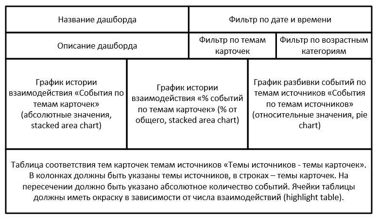

```python
from IPython.display import Image
display('МАКЕТ ДАШБОРДА "Анализ взаимодействия пользователей с карточками Яндекс.Дзен"')
Image(filename='Макет дашборда.png')
```

**План работы по проекту:**

1. Создать подключение к базе данных 'data-analyst-zen-project-db'.
2. Выполнить sql-запрос и получить данные для выгрузки в файл.
3. Выгрузить данные из таблицы dash_visits в файл dash_visits.csv.
4. В Tableau Public на основе файла dash_visits.csv сформировать дашборд в соответствии с указанным макетом и опубликовать его.
5. Подготовить небольшую презентацию с отчётом — ответы на вопросы и графики.

## Получение и изучение исходных данных

```python
import pandas as pd
import datetime as dt
from IPython.display import display
from sqlalchemy import create_engine
from datetime import datetime
```

```python
# создаем подключение к базе данных, загружаем таблицу и выгружаем данные в файл:
# Задаём параметры подключения к БД
db_config = {'user': '***************', # имя пользователя
            'pwd': '****************', # пароль
            'host': '**************.mdb.yandexcloud.net',
            'port': ****, # порт подключения
            'db': 'data-analyst-zen-project-db'} # название базы данных

# Формируем строку соединения с БД
connection_string = 'postgresql://{}:{}@{}:{}/{}'.format(db_config['user'],
                                                db_config['pwd'],
                                                db_config['host'],
                                                db_config['port'],
                                                db_config['db'])
# Подключаемся к БД
engine = create_engine(connection_string)

# Формируем sql-запрос.
query = ''' SELECT *
            FROM dash_visits
        '''
#посмотрим, что имеем как результат запроса
dash_visits=pd.io.sql.read_sql(query, con = engine)
print(dash_visits.head(10))
```

```
   record_id item_topic source_topic age_segment                  dt  visits
0    1040597     Деньги         Авто       18-25 2019-09-24 18:32:00       3
1    1040598     Деньги         Авто       18-25 2019-09-24 18:35:00       1
2    1040599     Деньги         Авто       18-25 2019-09-24 18:54:00       4
3    1040600     Деньги         Авто       18-25 2019-09-24 18:55:00      17
4    1040601     Деньги         Авто       18-25 2019-09-24 18:56:00      27
5    1040602     Деньги         Авто       18-25 2019-09-24 18:57:00      22
6    1040603     Деньги         Авто       18-25 2019-09-24 18:58:00      24
7    1040604     Деньги         Авто       18-25 2019-09-24 18:59:00      20
8    1040605     Деньги         Авто       18-25 2019-09-24 19:00:00       5
9    1040606     Деньги         Авто       26-30 2019-09-24 18:29:00       1
```

```python
def get_df_name(df):            #получаем имя проверяемого датафрейма
    name =[x for x in globals() if globals()[x] is df][0]
    return name

#Функция проверки датафрейма на дубликаты, пропуски, вывод информации
#о датафрейме, описат. статистики
def checking_data(df):

    print('Данные по датафрейму', get_df_name(df), ':')
    print()
    display(df.head())
    #Проверим наличие дубликатов строк
    print('Дубликатов строк в датафрейме:', df.duplicated().sum())
    print('')
    print('Количество пропусков в данных в столбцах:')
    empty_cells = pd.Series(df.isna().sum())
    empty_cells = pd.DataFrame(empty_cells, columns=['total_blanks'])
    empty_cells['share_blanks, %'] = round(empty_cells['total_blanks']/\
                df.shape[0]*100, 2) #считаем доли пропусков в общем количестве
    display(empty_cells)
    print('')
    print('_'*25, 'dataframe info: ', '_'*25)
    # изучим информацию о типах данных в столбцах и размере датафрейма,
    #возможных пропусках в данных
    df.info()
    print('')
    #попытаемся понять, есть ли аномальные значения
    print('Описательная статистика датафрейма:')
    display(df.describe().round(2));
```

```python
#проверяем датафрейм на дубликаты, пропуски, вывод информации
#о датафрейме,описат. статистики
print(checking_data(dash_visits))
```

```
Данные по датафрейму dash_visits :
```

|  | record_id | item_topic | source_topic | age_segment | dt | visits |
| --- | --- | --- | --- | --- | --- | --- |
| 0 | 1040597 | Деньги | Авто | 18-25 | 2019-09-24 18:32:00 | 3 |
| 1 | 1040598 | Деньги | Авто | 18-25 | 2019-09-24 18:35:00 | 1 |
| 2 | 1040599 | Деньги | Авто | 18-25 | 2019-09-24 18:54:00 | 4 |
| 3 | 1040600 | Деньги | Авто | 18-25 | 2019-09-24 18:55:00 | 17 |
| 4 | 1040601 | Деньги | Авто | 18-25 | 2019-09-24 18:56:00 | 27 |

```
Дубликатов строк в датафрейме: 0

Количество пропусков в данных в столбцах:
```

|  | total_blanks | share_blanks, % |
| --- | --- | --- |
| record_id | 0 | 0.0 |
| item_topic | 0 | 0.0 |
| source_topic | 0 | 0.0 |
| age_segment | 0 | 0.0 |
| dt | 0 | 0.0 |
| visits | 0 | 0.0 |

```
_________________________ dataframe info:  _________________________
<class 'pandas.core.frame.DataFrame'>
RangeIndex: 30745 entries, 0 to 30744
Data columns (total 6 columns):
 #   Column        Non-Null Count  Dtype
---  ------        --------------  -----
 0   record_id     30745 non-null  int64
 1   item_topic    30745 non-null  object
 2   source_topic  30745 non-null  object
 3   age_segment   30745 non-null  object
 4   dt            30745 non-null  datetime64[ns]
 5   visits        30745 non-null  int64
dtypes: datetime64[ns](1), int64(2), object(3)
memory usage: 1.4+ MB

Описательная статистика датафрейма:
```

|  | record_id | visits |
| --- | --- | --- |
| count | 30745.00 | 30745.00 |
| mean | 1055969.00 | 10.09 |
| std | 8875.46 | 19.73 |
| min | 1040597.00 | 1.00 |
| 25% | 1048283.00 | 1.00 |
| 50% | 1055969.00 | 3.00 |
| 75% | 1063655.00 | 10.00 |
| max | 1071341.00 | 371.00 |

```
None
```

```python
#Дата начала сбора данных и дата окончания сбора данных:
print('Начало сбора данных:', dash_visits['dt'].min())
print('Окончание сбора данных:', dash_visits['dt'].max())
```

```
Начало сбора данных: 2019-09-24 18:28:00
Окончание сбора данных: 2019-09-24 19:00:00
```

```python
#сохраняем результат запроса в файл 'dash_visits.csv' на диск
dash_visits.to_csv('dash_visits.csv', index=False)
```

**Подитог изучения исходных данных:**  
Имеем 30745 записей о событиях в исходных данных.  
Дубликатов строк в датафрейме нет.  
Пропусков нет. Типы значений в столбцах соответствуют содержанию.  
Начало сбора данных: 2019-09-24 18:28:00  
Окончание сбора данных: 2019-09-24 19:00:00

Таблица с данными выгружена в файл 'dash_visits.csv', необходимый для дашборда.

## Создание дашборда в Tableau Public

Состав данных в дашборде "Анализ взаимодействия пользователей с карточками Яндекс.Дзен":

Для более тонкой настройки анализа имеются три фильтра:

1. Период времени.
2. Тема карточки.
3. Возрастная группа.

Событие: либо карточка отображена для пользователя (show); либо пользователь кликнул на карточку (click); либо пользователь просмотрел статью карточки (view).

## Файл с презентацией, графиками

**Ссылка на файл презентации:** [Анализ взаимодействия пользователей с карточками статей ЯндексДзен](https://drive.google.com/file/d/1BSm7jXydQH1XPPPbvnxj70CI32ZbqjBH/view?usp=sharing)

**Ссылка на дашборд:** [Интерактивный дашборд "Взаимодействие пользователей с карточками статей ЯндексДзен"](https://public.tableau.com/app/profile/s.s6552/viz/Dash_visits_16794269844230/Dzen?publish=yes)